# Raport HW3

Maciej Szpetmański

2022-11-22

## Wstęp

Celem przeprowadzonego przeze mnie badania było sprawdzenie dokładności odczytu danych z trzech typów wykresów: kołowego, słupkowego bez siatki i tradycyjnego słupkowego. W tym celu została przygotowana przeze mnie ankieta zawierająca 5 pytań i miejsce na komentarze dotyczące odbioru poszczególnych wykresów. W pytaniach ankietowani mieli za zadanie odczytanie lub porównanie odpowiednich wartości. Grupą badawczą była grupa studentów filozofii na Uniwersytecie Marii Curie-Skłodowskiej w Lublinie.

Ankieta: https://forms.gle/7crjmETBKqL69C236

## Sporządzone wykresy, wyniki ankiety i ich analiza

# Wykres kołowy

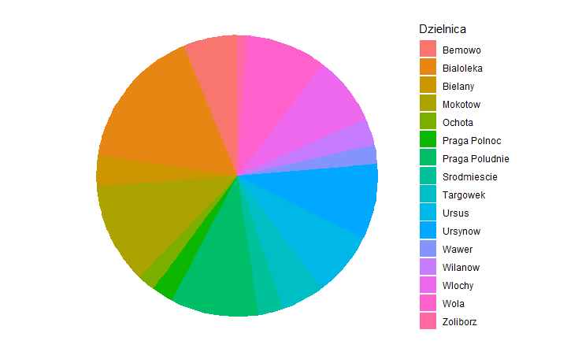

*Img. 1: Wykres kołowy*

# Wyniki postawionych pytań

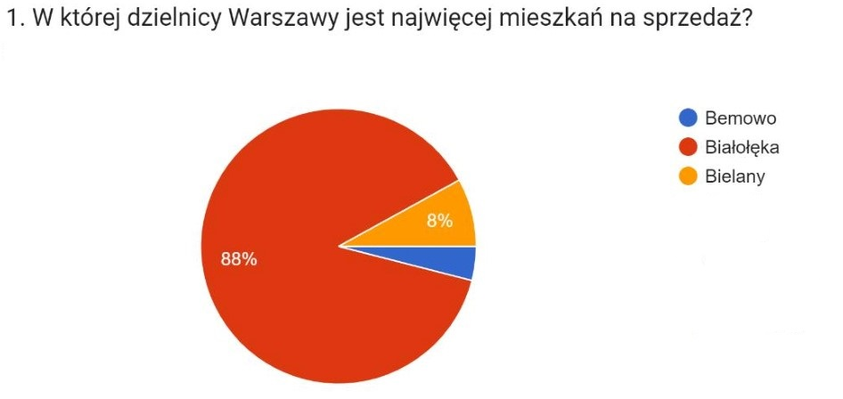

*Img. 2: Wyniki dla pierwszego pytania do wykresu kołowego*

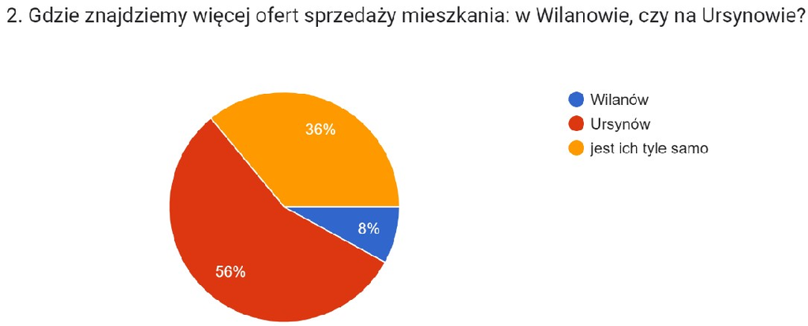

*Img. 3: Wyniki dla drugiego pytania do wykresu kołowego*

# Analiza wyników:

Dwa pierwsze pytania w mojej ankiecie dotyczyły wykresu kołowego. W pierwszym pytaniu poprosiłem o wskazanie dzielnicy, w której znajduje się najwięcej mieszkań na sprzedarz. Poprawną odpowiedzią na to pytanie była Białołęka i jak możemy zauważyć na wykresie 88% badanych takiej właśnie odpowiedzi udzieliło. Nie jest to jednak zaskakujące, ponieważ odpowiedź na wykresie zajmuje zauważalnie dużą część w porównaniu do pozostałych, jest ona również zaznaczona w miarę dobrze widocznym kolorem. Pozostałe 12% można w tym wypadku uznać za pomyłkę przy odpowiedzi lub za spowodowane problemami z rozróznianiem barw. W pytaniu drugim chodziło o porównanie liczby ofert mieszkaniowych w dwóch dzielnicach. Poprawną odpowiedź (Ursynów), wybrała nieco ponad połowa respondentów - 56%. Wyniki te wskazują na to, że ludzkie oko ma problemy z dobrym odczytywaniem kątów.

# Wykresy słupkowe

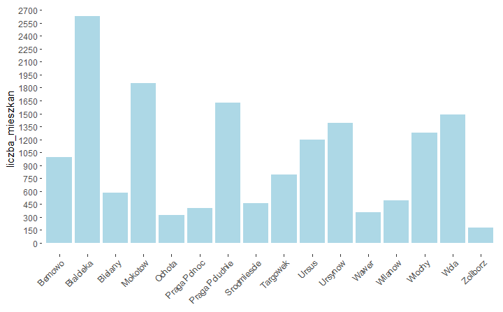

*Img. 4: Wykres słupkowy bez siatki*

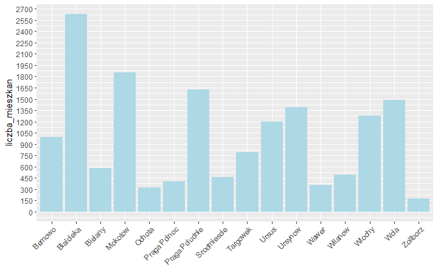

*Img. 5: Wykres słupkowy z siatką*

# Wyniki postawionego pytania

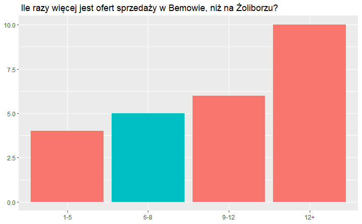

*Img. 6: Wyniki dla pytania do wykresu nr 2*

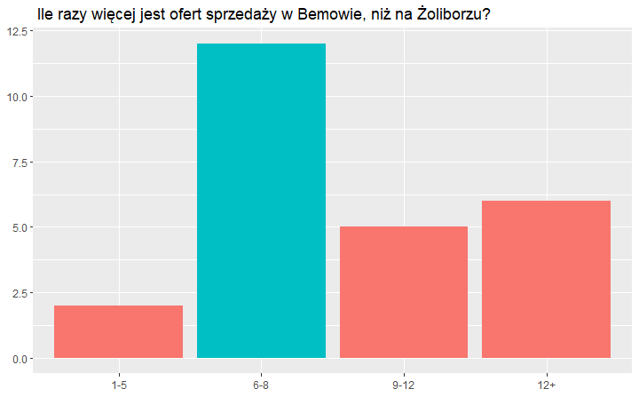

*Img. 7: Wyniki dla pytania do wykresu nr 3*

# Analiza wyników:

To pytanie miało za zadanie sprawdzić, czy obecność siatki na wykresie ma duży wpływ na jego odczyt. Za poprawne odpowiedzi były uznawane te, które znalazły się w przedziale 6-8, zaznaczonym na wykresach kolorem niebieskim. Jak możemy zauważyć dodanie siatki w tle wykresu, przyczyniło się do znacznego wzrostu w liczbie poprawnych odpowiedzi.

## Wnioski

Wyniki potwierdzają tezę, że człowiek najlepiej odczytuje wykresy w formie słupkowej, co potwierdzają także komentarze ankietowanych. Wykresy kołowe z powodu nieprawidłowego odczytywania wielkości kątów są znacznie cięższe do odczytania. Dodatkowo z powodu konieczności użycia kolorów, osoby posiadające problemy z dostrzeganiem barw mogą nie móc wyciągnąć z grafiki żadnych wniosków.